# Travel Package Purchase Prediction

### Key analysis objectives of the Project

At "Visit with us",the Policy Maker of the company wants to enable and establish a viable business model to expand the customer base.Company wants to harness the available data of existing and potential customers to make the marketing expenditure more efficient.

##### Objective:

To predict which customer is more likely to purchase the newly introduced travel package

### Data Context

##### Customer details:

1. CustomerID: Unique customer ID
2. ProdTaken: Whether the customer has purchased a package or not (0: No, 1: Yes)
3. Age: Age of customer
4. TypeofContact: How customer was contacted (Company Invited or Self Inquiry)
5. CityTier: City tier depends on the development of a city, population, facilities, and living standards. The categories are ordered i.e. Tier 1 > Tier 2 > Tier 3
6. Occupation: Occupation of customer
7. Gender: Gender of customer
8. NumberOfPersonVisiting: Total number of persons planning to take the trip with the customer
9. PreferredPropertyStar: Preferred hotel property rating by customer
10. MaritalStatus: Marital status of customer
11. NumberOfTrips: Average number of trips in a year by customer
12. Passport: The customer has a passport or not (0: No, 1: Yes)
13. OwnCar: Whether the customers own a car or not (0: No, 1: Yes)
14. NumberOfChildrenVisiting: Total number of children with age less than 5 planning to take the trip with the customer
15. Designation: Designation of the customer in the current organization
16. MonthlyIncome: Gross monthly income of the customer

##### Customer interaction data:

1. PitchSatisfactionScore: Sales pitch satisfaction score
2. ProductPitched: Product pitched by the salesperson
3. NumberOfFollowups: Total number of follow-ups has been done by the salesperson after the sales pitch
4. DurationOfPitch: Duration of the pitch by a salesperson to the customer

#### Importing all the required packages for the project:

```python
import pandas as pd #importing Pandas for dataset import
import matplotlib.pyplot as plt #importing for basic visualization and seaborn
import seaborn as sns #importing for better visualization features
import warnings # importing to suppress the warnings of deprecated features
import numpy as np #importing numpy
warnings.filterwarnings('ignore') # suppress the warnings
#for inline plotting
%matplotlib inline
pd.set_option('display.float_format', lambda x: '%.5f' % x) #to suppress scientific notations
# Removes the limit for the number of displayed columns
pd.set_option("display.max_columns", None)
# Sets the limit for the number of displayed rows
pd.set_option("display.max_rows", 200)
# To build linear model for prediction
from sklearn.linear_model import LinearRegression
# To check model performance
from sklearn.model_selection import train_test_split
# Sets the limit for the number of displayed rows
pd.set_option("display.max_rows", 200)
# Libraries to build decision tree classifier
from sklearn.tree import DecisionTreeClassifier
from sklearn.ensemble import BaggingClassifier, RandomForestClassifier
from sklearn import tree
# To tune different models
from sklearn.model_selection import GridSearchCV
from sklearn import metrics
from sklearn.tree import DecisionTreeRegressor
from sklearn.ensemble import BaggingRegressor,RandomForestRegressor, GradientBoostingRegressor, AdaBoostRegressor, StackingRegressor
from xgboost import XGBRegressor, XGBClassifier
from sklearn.ensemble import AdaBoostClassifier, GradientBoostingClassifier
```

#### Read in the dataset using pandas

```python
#importing dataset stored in csv file and setting 1st cloumn as index
df = pd.read_excel(r'C:\Users\user\Desktop\AI_ML_Austin\notebook prog files\ProjectWork4\Tourism.xlsx', 'Tourism')
# creating a copy of the data so that original data remains unchanged
purpredf1 = df.copy()
```

#### To assess the data set (Top 10)

```python
purpredf1.head(10) #display top 10 rows
```

|  | CustomerID | ProdTaken | Age | TypeofContact | CityTier | DurationOfPitch | Occupation | Gender | NumberOfPersonVisiting | NumberOfFollowups | ProductPitched | PreferredPropertyStar | MaritalStatus | NumberOfTrips | Passport | PitchSatisfactionScore | OwnCar | NumberOfChildrenVisiting | Designation | MonthlyIncome |
| --- | --- | --- | --- | --- | --- | --- | --- | --- | --- | --- | --- | --- | --- | --- | --- | --- | --- | --- | --- | --- |
| 0 | 200000 | 1 | 41.00000 | Self Enquiry | 3 | 6.00000 | Salaried | Female | 3 | 3.00000 | Deluxe | 3.00000 | Single | 1.00000 | 1 | 2 | 1 | 0.00000 | Manager | 20993.00000 |
| 1 | 200001 | 0 | 49.00000 | Company Invited | 1 | 14.00000 | Salaried | Male | 3 | 4.00000 | Deluxe | 4.00000 | Divorced | 2.00000 | 0 | 3 | 1 | 2.00000 | Manager | 20130.00000 |
| 2 | 200002 | 1 | 37.00000 | Self Enquiry | 1 | 8.00000 | Free Lancer | Male | 3 | 4.00000 | Basic | 3.00000 | Single | 7.00000 | 1 | 3 | 0 | 0.00000 | Executive | 17090.00000 |
| 3 | 200003 | 0 | 33.00000 | Company Invited | 1 | 9.00000 | Salaried | Female | 2 | 3.00000 | Basic | 3.00000 | Divorced | 2.00000 | 1 | 5 | 1 | 1.00000 | Executive | 17909.00000 |
| 4 | 200004 | 0 | nan | Self Enquiry | 1 | 8.00000 | Small Business | Male | 2 | 3.00000 | Basic | 4.00000 | Divorced | 1.00000 | 0 | 5 | 1 | 0.00000 | Executive | 18468.00000 |
| 5 | 200005 | 0 | 32.00000 | Company Invited | 1 | 8.00000 | Salaried | Male | 3 | 3.00000 | Basic | 3.00000 | Single | 1.00000 | 0 | 5 | 1 | 1.00000 | Executive | 18068.00000 |
| 6 | 200006 | 0 | 59.00000 | Self Enquiry | 1 | 9.00000 | Small Business | Female | 2 | 2.00000 | Basic | 5.00000 | Divorced | 5.00000 | 1 | 2 | 1 | 1.00000 | Executive | 17670.00000 |
| 7 | 200007 | 0 | 30.00000 | Self Enquiry | 1 | 30.00000 | Salaried | Male | 3 | 3.00000 | Basic | 3.00000 | Married | 2.00000 | 0 | 2 | 0 | 1.00000 | Executive | 17693.00000 |
| 8 | 200008 | 0 | 38.00000 | Company Invited | 1 | 29.00000 | Salaried | Male | 2 | 4.00000 | Standard | 3.00000 | Unmarried | 1.00000 | 0 | 3 | 0 | 0.00000 | Senior Manager | 24526.00000 |
| 9 | 200009 | 0 | 36.00000 | Self Enquiry | 1 | 33.00000 | Small Business | Male | 3 | 3.00000 | Deluxe | 3.00000 | Divorced | 7.00000 | 0 | 3 | 1 | 0.00000 | Manager | 20237.00000 |

Its always better to check the random rows instead of top rows.

```python
np.random.seed(1) #random set with seed 1, so the same set of random values can be generated everytime
purpredf1.sample(n=20) #Print 20 random rows to check the dataset
```

|  | CustomerID | ProdTaken | Age | TypeofContact | CityTier | DurationOfPitch | Occupation | Gender | NumberOfPersonVisiting | NumberOfFollowups | ProductPitched | PreferredPropertyStar | MaritalStatus | NumberOfTrips | Passport | PitchSatisfactionScore | OwnCar | NumberOfChildrenVisiting | Designation | MonthlyIncome |
| --- | --- | --- | --- | --- | --- | --- | --- | --- | --- | --- | --- | --- | --- | --- | --- | --- | --- | --- | --- | --- |
| 3015 | 203015 | 0 | 27.00000 | Company Invited | 1 | 7.00000 | Salaried | Female | 4 | 6.00000 | Basic | 3.00000 | Married | 5.00000 | 0 | 4 | 1 | 3.00000 | Executive | 23042.00000 |
| 1242 | 201242 | 0 | 40.00000 | Self Enquiry | 3 | 13.00000 | Small Business | Male | 2 | 3.00000 | King | 4.00000 | Single | 2.00000 | 0 | 4 | 1 | nan | VP | 34833.00000 |
| 3073 | 203073 | 0 | 29.00000 | Self Enquiry | 2 | 15.00000 | Small Business | Male | 4 | 5.00000 | Basic | 3.00000 | Married | 3.00000 | 0 | 2 | 0 | 2.00000 | Executive | 23614.00000 |
| 804 | 200804 | 0 | 48.00000 | Company Invited | 1 | 6.00000 | Small Business | Male | 2 | 1.00000 | Super Deluxe | 3.00000 | Single | 3.00000 | 0 | 2 | 0 | 0.00000 | AVP | 31885.00000 |
| 3339 | 203339 | 0 | 32.00000 | Self Enquiry | 1 | 18.00000 | Small Business | Male | 4 | 4.00000 | Deluxe | 5.00000 | Divorced | 3.00000 | 1 | 2 | 0 | 3.00000 | Manager | 25511.00000 |
| 3080 | 203080 | 1 | 36.00000 | Company Invited | 1 | 32.00000 | Salaried | Female | 4 | 4.00000 | Basic | 4.00000 | Married | 3.00000 | 1 | 3 | 0 | 1.00000 | Executive | 20700.00000 |
| 2851 | 202851 | 0 | 46.00000 | Self Enquiry | 1 | 17.00000 | Salaried | Male | 4 | 4.00000 | Basic | 3.00000 | Divorced | 5.00000 | 0 | 5 | 1 | 1.00000 | Executive | 21332.00000 |
| 2883 | 202883 | 1 | 32.00000 | Company Invited | 1 | 27.00000 | Salaried | Male | 4 | 4.00000 | Standard | 3.00000 | Divorced | 5.00000 | 0 | 3 | 1 | 1.00000 | Senior Manager | 28502.00000 |
| 1676 | 201676 | 0 | 22.00000 | Self Enquiry | 1 | 11.00000 | Salaried | Male | 2 | 1.00000 | Basic | 4.00000 | Married | 2.00000 | 1 | 4 | 1 | 0.00000 | Executive | 17328.00000 |
| 1140 | 201140 | 0 | 44.00000 | Self Enquiry | 1 | 13.00000 | Small Business | Female | 2 | 3.00000 | King | 3.00000 | Married | 1.00000 | 1 | 4 | 1 | 1.00000 | VP | 34049.00000 |
| 748 | 200748 | 1 | 26.00000 | Company Invited | 3 | 35.00000 | Small Business | Male | 3 | nan | Deluxe | 5.00000 | Single | 1.00000 | 0 | 3 | 0 | 0.00000 | Manager | 19969.00000 |
| 2394 | 202394 | 1 | nan | Company Invited | 1 | 8.00000 | Salaried | Female | 2 | 4.00000 | Basic | 5.00000 | Single | 3.00000 | 1 | 3 | 0 | 0.00000 | Executive | 18506.00000 |
| 4881 | 204881 | 1 | 41.00000 | Self Enquiry | 2 | 25.00000 | Salaried | Male | 3 | 2.00000 | Basic | 5.00000 | Married | 2.00000 | 0 | 1 | 1 | 2.00000 | Executive | 21065.00000 |
| 3415 | 203415 | 0 | 52.00000 | Self Enquiry | 1 | 18.00000 | Large Business | Female | 3 | 5.00000 | Super Deluxe | 4.00000 | Single | 5.00000 | 0 | 1 | 0 | 2.00000 | AVP | 31820.00000 |
| 2253 | 202253 | 0 | nan | Self Enquiry | 1 | 13.00000 | Large Business | Female | 2 | 1.00000 | Basic | 3.00000 | Married | 2.00000 | 0 | 3 | 0 | 0.00000 | Executive | 18376.00000 |
| 3685 | 203685 | 0 | 33.00000 | Self Enquiry | 3 | 26.00000 | Salaried | Male | 4 | 6.00000 | Standard | 3.00000 | Married | 5.00000 | 0 | 3 | 1 | 3.00000 | Senior Manager | 28288.00000 |
| 2722 | 202722 | 0 | 27.00000 | Company Invited | 1 | 7.00000 | Salaried | Female | 3 | 4.00000 | Deluxe | 4.00000 | Married | 3.00000 | 0 | 5 | 0 | 2.00000 | Manager | 25075.00000 |
| 2886 | 202886 | 0 | 37.00000 | Company Invited | 3 | 17.00000 | Small Business | Male | 3 | 4.00000 | Standard | 3.00000 | Single | 3.00000 | 0 | 2 | 1 | 2.00000 | Senior Manager | 28658.00000 |
| 4449 | 204449 | 0 | 42.00000 | Self Enquiry | 2 | 17.00000 | Salaried | Male | 4 | 5.00000 | King | 3.00000 | Married | nan | 0 | 1 | 1 | 2.00000 | VP | 37819.00000 |
| 1550 | 201550 | 0 | 30.00000 | Self Enquiry | 1 | 6.00000 | Salaried | Male | 2 | 4.00000 | Deluxe | 3.00000 | Married | 2.00000 | 1 | 1 | 1 | 1.00000 | Manager | 20126.00000 |

The dataset looks consistent with the description provided in the Data Dictionary. Lots of data have values which need to be processed so the data can be effectively used for analysis

#### Check the shape of the provided data

```python
print(f'There are {purpredf1.shape[0]} rows and {purpredf1.shape[1]} columns.')  # f-string
```

```
There are 4888 rows and 20 columns.
```

There are 4888 rows/observations of 20 columns

#### Check datatype count

```python
purpredf1.dtypes.value_counts() #Gives count of the different datatype in dataset
```

```
int64      7
float64    7
object     6
dtype: int64
```

#### Get the complete info of the dataset

```python
purpredf1.info() #display complete info
```

```
<class 'pandas.core.frame.DataFrame'>
RangeIndex: 4888 entries, 0 to 4887
Data columns (total 20 columns):
 #   Column                    Non-Null Count  Dtype
---  ------                    --------------  -----
 0   CustomerID                4888 non-null   int64
 1   ProdTaken                 4888 non-null   int64
 2   Age                       4662 non-null   float64
 3   TypeofContact             4863 non-null   object
 4   CityTier                  4888 non-null   int64
 5   DurationOfPitch           4637 non-null   float64
 6   Occupation                4888 non-null   object
 7   Gender                    4888 non-null   object
 8   NumberOfPersonVisiting    4888 non-null   int64
 9   NumberOfFollowups         4843 non-null   float64
 10  ProductPitched            4888 non-null   object
 11  PreferredPropertyStar     4862 non-null   float64
 12  MaritalStatus             4888 non-null   object
 13  NumberOfTrips             4748 non-null   float64
 14  Passport                  4888 non-null   int64
 15  PitchSatisfactionScore    4888 non-null   int64
 16  OwnCar                    4888 non-null   int64
 17  NumberOfChildrenVisiting  4822 non-null   float64
 18  Designation               4888 non-null   object
 19  MonthlyIncome             4655 non-null   float64
dtypes: float64(7), int64(7), object(6)
memory usage: 763.9+ KB
```

#### Checking for missing values in the data

```python
purpredf1.isnull().sum()
```

```
CustomerID                    0
ProdTaken                     0
Age                         226
TypeofContact                25
CityTier                      0
DurationOfPitch             251
Occupation                    0
Gender                        0
NumberOfPersonVisiting        0
NumberOfFollowups            45
ProductPitched                0
PreferredPropertyStar        26
MaritalStatus                 0
NumberOfTrips               140
Passport                      0
PitchSatisfactionScore        0
OwnCar                        0
NumberOfChildrenVisiting     66
Designation                   0
MonthlyIncome               233
dtype: int64
```

**Number of unique values in each column**

```python
purpredf1.nunique()
```

```
CustomerID                  4888
ProdTaken                      2
Age                           44
TypeofContact                  2
CityTier                       3
DurationOfPitch               34
Occupation                     4
Gender                         3
NumberOfPersonVisiting         5
NumberOfFollowups              6
ProductPitched                 5
PreferredPropertyStar          3
MaritalStatus                  4
NumberOfTrips                 12
Passport                       2
PitchSatisfactionScore         5
OwnCar                         2
NumberOfChildrenVisiting       4
Designation                    5
MonthlyIncome               2475
dtype: int64
```

#### Describe all columns

```python
purpredf1.describe(include="all").T #describe all dataset. Use transpose so column wise details can be view from top to bottompurpredf1.describe(include="all").T #describe all dataset. Use transpose so column wise details can be view from top to bottom
```

|  | count | unique | top | freq | mean | std | min | 25% | 50% | 75% | max |
| --- | --- | --- | --- | --- | --- | --- | --- | --- | --- | --- | --- |
| CustomerID | 4888.00000 | NaN | NaN | NaN | 202443.50000 | 1411.18839 | 200000.00000 | 201221.75000 | 202443.50000 | 203665.25000 | 204887.00000 |
| ProdTaken | 4888.00000 | NaN | NaN | NaN | 0.18822 | 0.39092 | 0.00000 | 0.00000 | 0.00000 | 0.00000 | 1.00000 |
| Age | 4662.00000 | NaN | NaN | NaN | 37.62227 | 9.31639 | 18.00000 | 31.00000 | 36.00000 | 44.00000 | 61.00000 |
| TypeofContact | 4863 | 2 | Self Enquiry | 3444 | NaN | NaN | NaN | NaN | NaN | NaN | NaN |
| CityTier | 4888.00000 | NaN | NaN | NaN | 1.65426 | 0.91658 | 1.00000 | 1.00000 | 1.00000 | 3.00000 | 3.00000 |
| DurationOfPitch | 4637.00000 | NaN | NaN | NaN | 15.49083 | 8.51964 | 5.00000 | 9.00000 | 13.00000 | 20.00000 | 127.00000 |
| Occupation | 4888 | 4 | Salaried | 2368 | NaN | NaN | NaN | NaN | NaN | NaN | NaN |
| Gender | 4888 | 3 | Male | 2916 | NaN | NaN | NaN | NaN | NaN | NaN | NaN |
| NumberOfPersonVisiting | 4888.00000 | NaN | NaN | NaN | 2.90507 | 0.72489 | 1.00000 | 2.00000 | 3.00000 | 3.00000 | 5.00000 |
| NumberOfFollowups | 4843.00000 | NaN | NaN | NaN | 3.70845 | 1.00251 | 1.00000 | 3.00000 | 4.00000 | 4.00000 | 6.00000 |
| ProductPitched | 4888 | 5 | Basic | 1842 | NaN | NaN | NaN | NaN | NaN | NaN | NaN |
| PreferredPropertyStar | 4862.00000 | NaN | NaN | NaN | 3.58104 | 0.79801 | 3.00000 | 3.00000 | 3.00000 | 4.00000 | 5.00000 |
| MaritalStatus | 4888 | 4 | Married | 2340 | NaN | NaN | NaN | NaN | NaN | NaN | NaN |
| NumberOfTrips | 4748.00000 | NaN | NaN | NaN | 3.23652 | 1.84902 | 1.00000 | 2.00000 | 3.00000 | 4.00000 | 22.00000 |
| Passport | 4888.00000 | NaN | NaN | NaN | 0.29092 | 0.45423 | 0.00000 | 0.00000 | 0.00000 | 1.00000 | 1.00000 |
| PitchSatisfactionScore | 4888.00000 | NaN | NaN | NaN | 3.07815 | 1.36579 | 1.00000 | 2.00000 | 3.00000 | 4.00000 | 5.00000 |
| OwnCar | 4888.00000 | NaN | NaN | NaN | 0.62029 | 0.48536 | 0.00000 | 0.00000 | 1.00000 | 1.00000 | 1.00000 |
| NumberOfChildrenVisiting | 4822.00000 | NaN | NaN | NaN | 1.18727 | 0.85786 | 0.00000 | 1.00000 | 1.00000 | 2.00000 | 3.00000 |
| Designation | 4888 | 5 | Executive | 1842 | NaN | NaN | NaN | NaN | NaN | NaN | NaN |
| MonthlyIncome | 4655.00000 | NaN | NaN | NaN | 23619.85349 | 5380.69836 | 1000.00000 | 20346.00000 | 22347.00000 | 25571.00000 | 98678.00000 |

## EDA

```python
# function to plot a boxplot and a histogram along the same scale.
def histogram_boxplot(data, feature, figsize=(12, 7), kde=False, bins=None):
    f2, (ax_box2, ax_hist2) = plt.subplots(
        nrows=2,  # Number of rows of the subplot grid= 2
        sharex=True,  # x-axis will be shared among all subplots
        gridspec_kw={"height_ratios": (0.25, 0.75)},
        figsize=figsize,
    )  # creating the 2 subplots
    sns.boxplot(
        data=data, x=feature, ax=ax_box2, showmeans=True, color="violet"
    )  # boxplot will be created and a star will indicate the mean value of the column
    sns.histplot(
        data=data, x=feature, kde=kde, ax=ax_hist2, bins=bins, palette="winter"
    ) if bins else sns.histplot(
        data=data, x=feature, kde=kde, ax=ax_hist2
    )  # For histogram
    ax_hist2.axvline(
        data[feature].mean(), color="green", linestyle="--"
    )  # Add mean to the histogram
    ax_hist2.axvline(
        data[feature].median(), color="black", linestyle="-"
    )  # Add median to the histogram
```

```python
# function to label barplot
def labeled_barplot(data, feature, perc=False, n=None):
    total = len(data[feature])  # length of the column
    count = data[feature].nunique()
    if n is None:
        plt.figure(figsize=(count + 1, 5))
    else:
        plt.figure(figsize=(n + 1, 5))

    plt.xticks(rotation=90, fontsize=15)
    ax = sns.countplot(
        data=data,
        x=feature,
        palette="Paired",
        order=data[feature].value_counts().index[:n].sort_values(),
    )

    for p in ax.patches:
        if perc == True:
            label = "{:.1f}%".format(
                100 * p.get_height() / total
            )  # percentage of each class of the category
        else:
            label = p.get_height()  # count of each level of the category

        x = p.get_x() + p.get_width() / total  # width of the plot
        y = p.get_y() + p.get_height() + 1.5  # height of the plot

        ax.annotate(label, (x, y), size=12, rotation=0)  # annotate the percentage

    plt.show()  # show the plot
```

### Data Analysis: Univariate Analysis

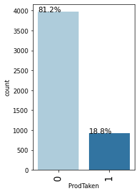

```python
labeled_barplot(purpredf1, "ProdTaken", perc=True) #barplot
```

Almost 19% of customers opted for products but 81% customers have not opted for any product.

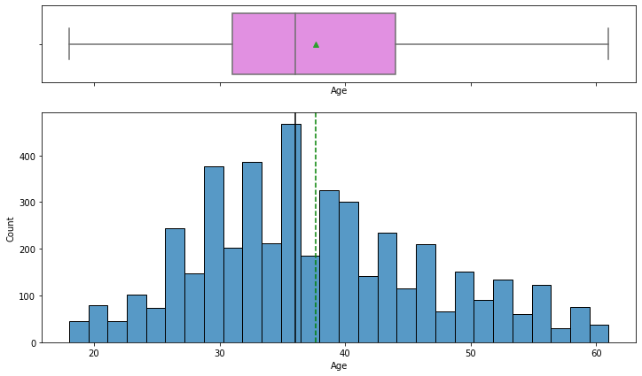

```python
histogram_boxplot(purpredf1, "Age") #boxplot
```

Age has an approx symmetric distribution with mean and median almost nearby There are not many outliers in the distribution for this variable

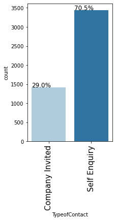

```python
labeled_barplot(purpredf1, "TypeofContact", perc=True) #barplot
```

70% are self enquiries and 29% are Company invited.

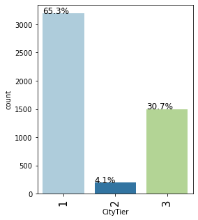

```python
labeled_barplot(purpredf1, "CityTier", perc=True) #barplot
```

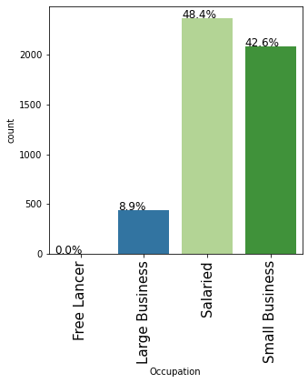

```python
labeled_barplot(purpredf1, "Occupation", perc=True) #barplot
```

Most of the customers are either salaried or having small businesses

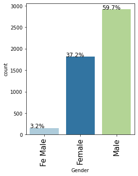

```python
labeled_barplot(purpredf1, "Gender", perc=True) #barplot
```

There is 60% - 40% distribution between male and female customers. Data correction is required for data value (FeMale)

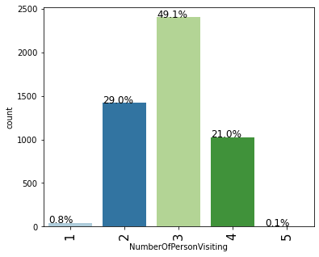

```python
labeled_barplot(purpredf1, "NumberOfPersonVisiting", perc=True) #barplot
```

Highest number of people visiting are 3

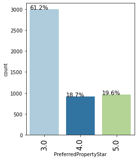

```python
labeled_barplot(purpredf1, "PreferredPropertyStar", perc=True) #barplot
```

Most used property is 3 Star

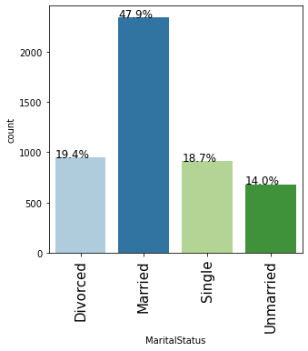

```python
labeled_barplot(purpredf1, "MaritalStatus", perc=True) #barplot
```

Almost 50% of customers are married

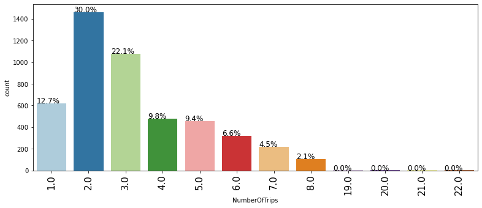

```python
labeled_barplot(purpredf1, "NumberOfTrips", perc=True) #barplot
```

Highest number of customers have booked 2 trips. There are many outliers.

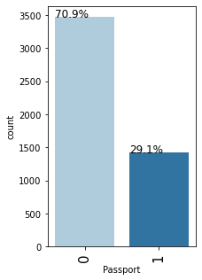

```python
labeled_barplot(purpredf1, "Passport", perc=True) #barplot
```

70% of customers don't have passports and 30% have.

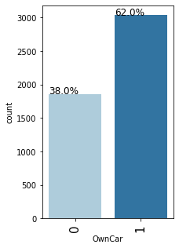

```python
labeled_barplot(purpredf1, "OwnCar", perc=True) #barplot
```

62% of customers own car and 38% don't

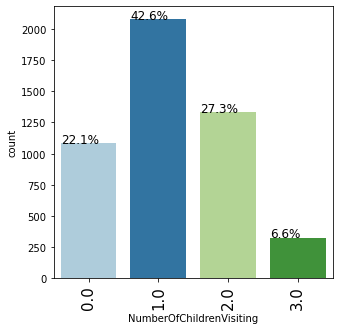

```python
labeled_barplot(purpredf1, "NumberOfChildrenVisiting", perc=True) #barplot
```

Almost 80% of customers have 1-3 children.

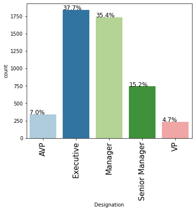

```python
labeled_barplot(purpredf1, "Designation", perc=True) #barplot
```

Most of the customers are Executives or Managers (approx 70%)

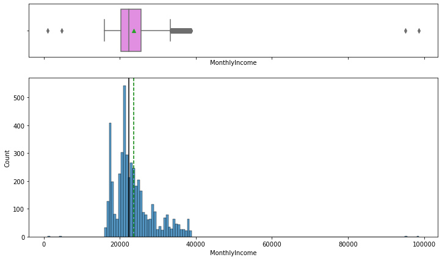

```python
histogram_boxplot(purpredf1, "MonthlyIncome") #boxplot
```

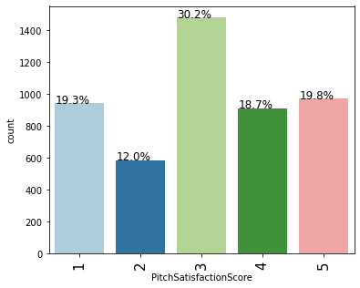

```python
labeled_barplot(purpredf1, "PitchSatisfactionScore", perc=True) #barplot
```

80% of the customers are not fully satisfied and almost 30% have given below average ratings

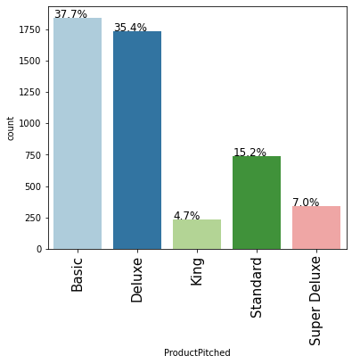

```python
labeled_barplot(purpredf1, "ProductPitched", perc=True) #barplot
```

70% product pitched are Basic or deluxe

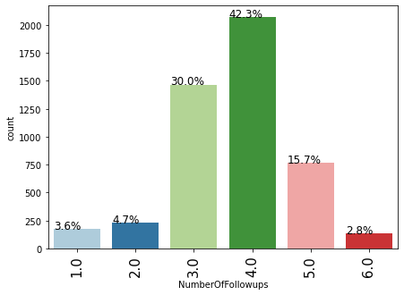

```python
labeled_barplot(purpredf1, "NumberOfFollowups", perc=True) #barplot
```

Most number of follow ups(approx 70%) lie between (3-4)

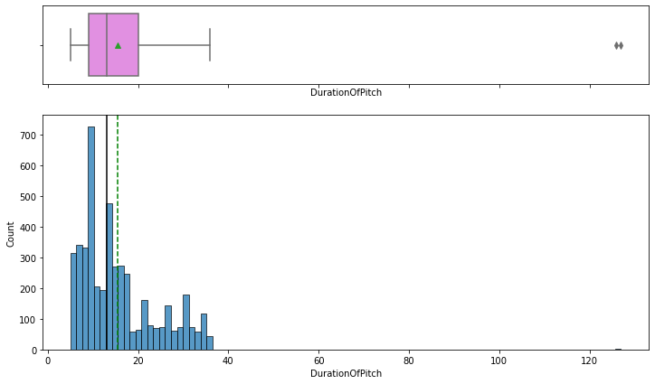

```python
histogram_boxplot(purpredf1, "DurationOfPitch") #boxplot
```

## Data Analysis: Bivariate Analysis

The pair plot between the values in dataset show the overall distribution against each of the columns. This give an overall view against the selected dataset values.

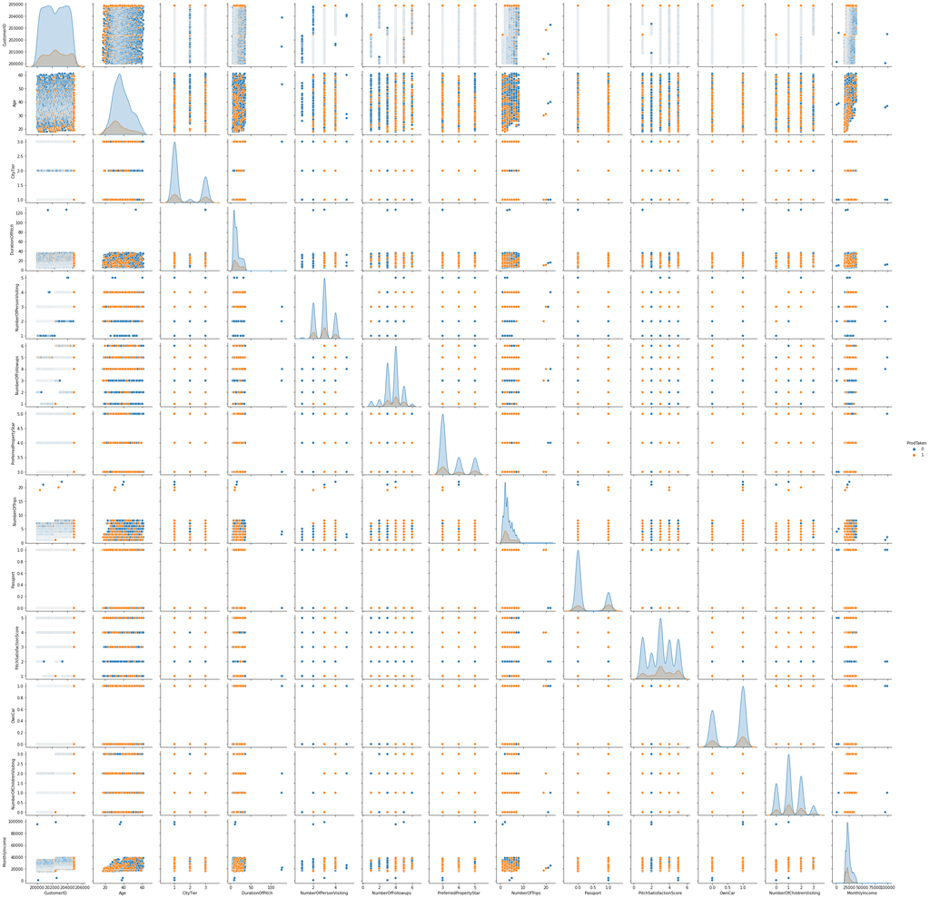

```python
sns.pairplot(purpredf1, hue="ProdTaken"); #pair plot multiple pair wise bivariate distributions
```

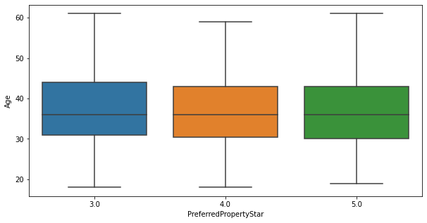

```python
plt.figure(figsize=(10, 5))
sns.boxplot(x="PreferredPropertyStar", y="Age", data=purpredf1) #plot to assess important variables
plt.show()
```

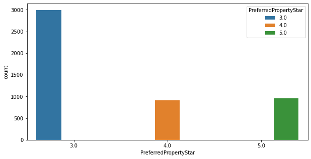

```python
plt.figure(figsize=(10, 5))
sns.countplot(x="PreferredPropertyStar", hue="PreferredPropertyStar", data=purpredf1); #plot to assess important variables
```

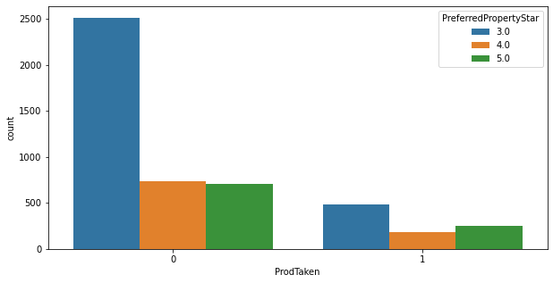

```python
plt.figure(figsize=(10, 5))
sns.countplot(x="ProdTaken", hue="PreferredPropertyStar", data=purpredf1); #plot to assess important variables
```

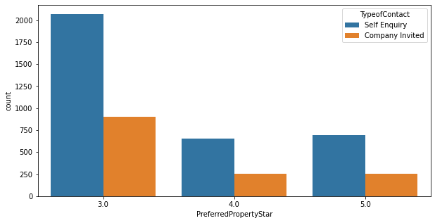

```python
plt.figure(figsize=(10, 5))
sns.countplot(x="PreferredPropertyStar", hue="TypeofContact", data=purpredf1); #plot to assess important variables
```

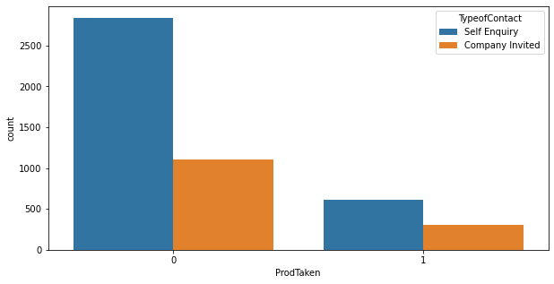

```python
plt.figure(figsize=(10, 5))
sns.countplot(x="ProdTaken", hue="TypeofContact", data=purpredf1); #plot to assess important variables
```

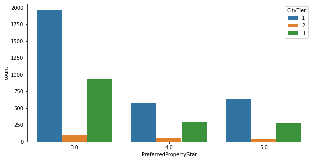

```python
plt.figure(figsize=(10, 5))
sns.countplot(x="PreferredPropertyStar", hue="CityTier", data=purpredf1); #plot to assess important variables
```

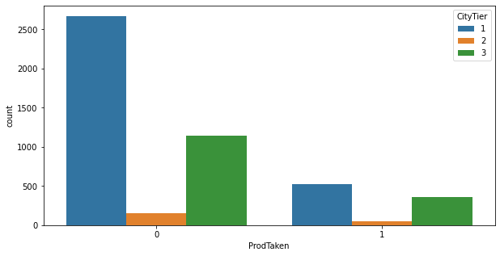

```python
plt.figure(figsize=(10, 5))
sns.countplot(x="ProdTaken", hue="CityTier", data=purpredf1); #plot to assess important variables
```